# Probability Distributions

## 均值与方差

所有离散分布的均值和方差都可以用以下公式计算： \[\mu=\sum[xP(x)]\] \[\sigma^2=\sum[(x-\mu)^2P(x)]\]

## 二项式分布

二项式分布非常简单，形象点说白球和黑球有放回抽样。

\[ P(X=r) = {n \choose r} p^r (1-p)^{n-r}\]

二项式分布的均值： \[ \mu = np \] 方差： \[ \sigma^2 = np(1-p)\]

n越大，二项式分布越接近于正态分布：

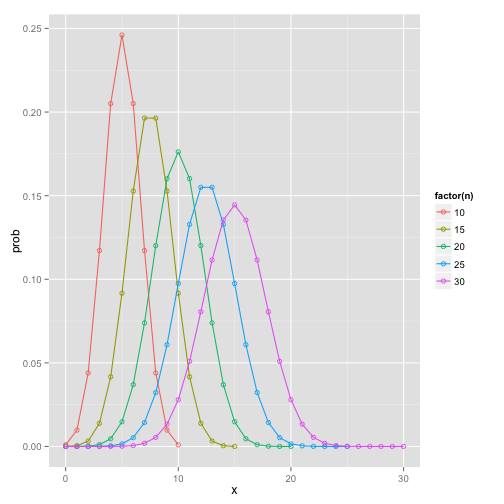

```r
bnd <- function(n, p = 0.5) {
    x <- seq(0, n)
    prob <- dbinom(x, n, p)
    df <- data.frame(x = x, prob = prob, n = n)
    return(df)
}
require(plyr)
bn.df <- mdply(data.frame(n = seq(10, 30, 5)), bnd)
ggplot(bn.df, aes(x, prob, group = n, color = factor(n))) + geom_point(shape = 1) +
    geom_line()
```

## Poisson分布

[Poisson分布是二项式分布的极限形式](http://episte.math.ntu.edu.tw/articles/sm/sm_16_07_1/),用于描述单位时间或空间里随机事件发生的次数，参数 \(\mu\) 表示单位时间或空间里某事件平均发生的次数。

\[P(X=x) = \frac{e^{-\lambda}\lambda^x}{x!}\]

Poisson分布的均值和方差相等： \(\mu = \sigma^2 = \lambda\) .

Poisson分布是右偏分布，均值越大时，其对称性越好：

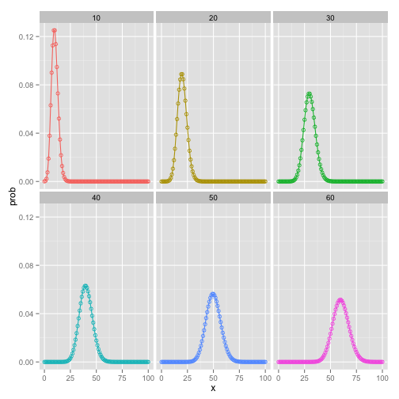

```r
pd <- function(x = 100, lambda) {
    x <- seq(0, x)
    prob <- dpois(x, lambda)
    df <- data.frame(x = x, prob = prob, lambda = lambda)
    return(df)
}
p.df <- mdply(data.frame(lambda = seq(10, 60, 10)), pd)
ggplot(p.df, aes(x, prob, group = lambda, color = factor(lambda))) + geom_point(shape = 1) +
    geom_line() + facet_wrap(~lambda) + theme(legend.position = "none")
```

## 正态分布

正态分布是边续型分布，我们关心的不是某个值的概率，而是概率密度函数下的面积，它的概率密度函数是： \[ f(x) = \frac{1}{\sqrt{2\pi\sigma^2}} e^{-(x-\mu)^2/2\sigma^2}\] 所有的正态分布，都可以标准化为均值为0，标准误为1的标准正态分布： \[ f(z) = \frac{1}{\sqrt{2\pi}} e^{-z^2/2}\] 其中 \(z=\frac{x-\mu}{\sigma}\) .

## t分布

如果总体是正态分布，那么样本均值的分布也呈正态，William S. Gosset发现了t分布，它在参数估计和统计检验上，比正态分布要好，在大样本上做的和正态分布一样好，而在小样本上，比正态分布好很多。

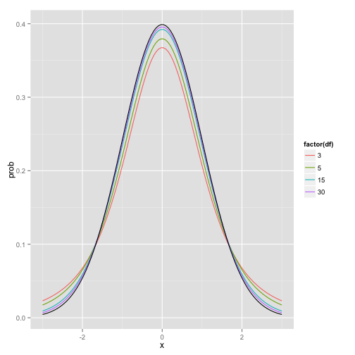

```r
require(plyr)
x <- seq(-3, 3, length = 100)
pn <- dnorm(x)
pn.df <- data.frame(x = x, prob = pn)

get.pt <- function(x, df) {
    prob <- dt(x, df = df)
    dd <- data.frame(x = x, prob = prob, df = df)
    return(dd)
}
para <- data.frame(x = rep(x, 4), df = rep(c(3, 5, 15, 30), each = length(x)))
pt.df <- mdply(para, get.pt)
require(ggplot2)
ggplot(pt.df, aes(x, prob)) + geom_line(aes(group = df, color = factor(df))) +
    geom_line(data = pn.df)
```

上图画了自由度为3，5，15和30的t分布，以及正态分布，随着自由度的增加，t分布越来越接近于正态分布，很多时候，我们只有小样本，那么可以说t分布是正态分布的保守版本.从图中可以观察到，t分布中心比较平，而尾巴比较”胖“，特别是自由度较小的时候，t分布的尾巴会比正态分布长，那么同样一个值，t分布计算出来的p-value会比正态分布大一点。

```r
dnorm(2)
```

```
## [1] 0.05399
```

```r
dt(2, df = 5)
```

```
## [1] 0.06509
```

## 卡方分布

k个独立的标准正态分布变量的平方和服从自由度为k的 \(\chi^2\) 分布，卡方分布常用于假设检验和置信区间的计算。

卡方分布被用于计算拟合优度，于观察到的分布和假设成立的分布之间；估算总体标准偏差(population standard deviation)和样本标准偏差(sample standard deviation)的区间。

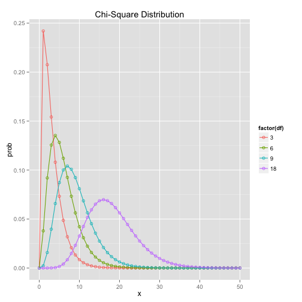

```r
pc <- function(x = 50, df) {
    x <- seq(0, x)
    prob <- dchisq(x, df)
    pc.df <- data.frame(x = x, prob = prob, df = df)
    return(pc.df)
}
pc.df <- mdply(data.frame(df = c(3, 6, 9, 18)), pc)
ggplot(pc.df, aes(x, prob, group = df, color = factor(df))) + geom_point(shape = 1) +
    geom_line() + ggtitle("Chi-Square Distribution")
```

## F分布

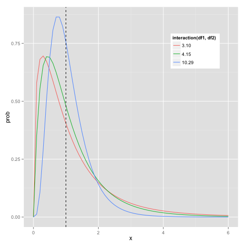

```r
pff <- function(x = seq(0, 6, 0.1), df1, df2) {
    y <- df(x, df1, df2)
    pf.df <- data.frame(x = x, prob = y, df1 = df1, df2 = df2)
    return(pf.df)
}

pf.df <- mdply(data.frame(df1 = c(3, 4, 10), df2 = c(10, 15, 29)), pff)
ggplot(pf.df, aes(x, prob, group = interaction(df1, df2), color = interaction(df1,
    df2))) + geom_line() + geom_vline(xintercept = 1, linetype = "dashed") +
    theme(legend.position = c(0.8, 0.8))
```

如果F值小于1，使用左尾巴进行p值计算，大于1则右尾巴进行p值计算，很多人抛弃使用左尾巴进行p值计算，只需要把分子分母倒过来就行，当然自由度也要跟着倒过来。

虽然使用单侧来计算，但p值的计算通常是two-tailed，因为F值是两个方差的比值，不管两个均值的差是正的还是负的，方差都是正的。从这个角度上看，计算出来的单侧p值要乘以2，要把正和负的均值差都考虑在内，这是双侧检验。 假如F值为4.5，自由度为10和15，p值应该这样算：

```r
2 * (1 - pf(4.5, 10, 15))
```

```
## [1] 0.009215
```

```
2013-06-20
```

[figure not shown]

[figure not shown]